# Commiting to a Fitness Challenge and Then Figuring Out if It Is Achievable

Matthew Routley

2019-02-12

My [favourite spin studio](https://www.torqride.com/) has put on a fitness challenge for 2019. It has many components, one of which is improving your performance by 3% over six weeks. I’ve taken on the challenge and am now worried that I don’t know how reasonable this increase actually is. So, a perfect excuse to extract my metrics and perform some excessive analysis.

We start by importing a CSV file of my stats, taken from Torq’s website. We use `readr` for this and set the `col_types` in advance to specify the type for each column, as well as skip some extra columns with `col_skip`. I find doing this at the same time as the import, rather than later in the process, more direct and efficient. I also like the flexibility of the `col_date` import, where I can convert the source data (e.g., “Mon 11/02/19 - 6:10 AM”) into a format [more useful for analysis](https://xkcd.com/1179/) (e.g., “2019-02-11”).

One last bit of clean up is to specify the instructors that have led 5 or more sessions. Later, we’ll try to identify an instructor-effect on my performance and only 5 of the 10 instructors have sufficient data for such an analysis. The `forcats::fct_other` function is really handy for this: it collapses several factor levels together into one “Other” level.

Lastly, I set the `challenge_start_date` variable for use later on.

```r
col_types = cols(
  Date = col_date(format = "%a %d/%m/%y - %H:%M %p"),
  Ride = col_skip(),
  Instructor = col_character(),
  Spot = col_skip(),
  `Avg RPM` = col_skip(),
  `Max RPM` = col_skip(),
  `Avg Power` = col_double(),
  `Max Power` = col_double(),
  `Total Energy` = col_double(),
  `Dist. (Miles)` = col_skip(),
  Cal. = col_skip(),
  `Class Rank` = col_skip()
)
main_instructors <- c("Tanis", "George", "Charlotte", "Justine", "Marawan") # 5 or more sessions
data <- readr::read_csv("torq_data.csv", col_types = col_types) %>%
  tibbletime::as_tbl_time(index = Date) %>%
  dplyr::rename(avg_power    = `Avg Power`,
                max_power    = `Max Power`,
                total_energy = `Total Energy`) %>%
  dplyr::mutate(Instructor =
                  forcats::fct_other(Instructor, keep = main_instructors))
challenge_start_date <- lubridate::as_date("2019-01-01")
head(data)
```

```
## # A time tibble: 6 x 5
## # Index: Date
##   Date       Instructor avg_power max_power total_energy
##   <date>     <fct>          <dbl>     <dbl>        <dbl>
## 1 2019-02-11 Justine          234       449          616
## 2 2019-02-08 George           221       707          577
## 3 2019-02-04 Justine          230       720          613
## 4 2019-02-01 George           220       609          566
## 5 2019-01-21 Justine          252       494          623
## 6 2019-01-18 George           227       808          590
```

To start, we just plot the change in average power over time. Given relatively high variability from class to class, we add a smoothed line to show the overall trend. We also mark the point where the challenge starts with a red line.

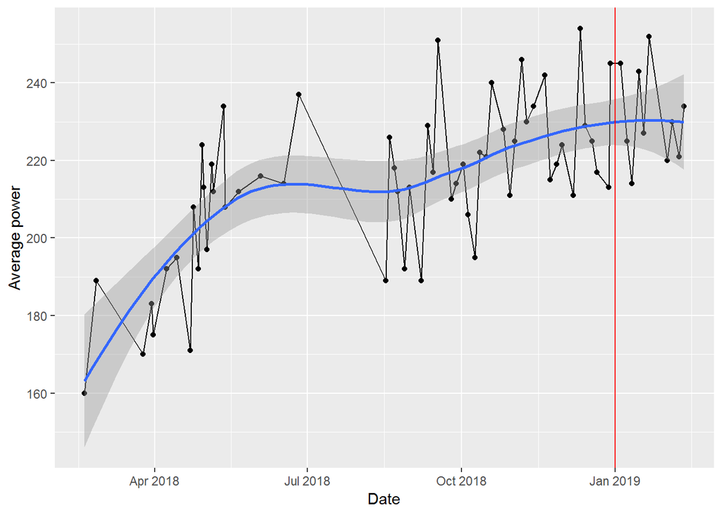

```r
ggplot2::ggplot(data, aes(x = Date, y = avg_power)) +
  ggplot2::geom_point() +
  ggplot2::geom_line() +
  geom_smooth(method = "loess") +
  ggplot2::ylab("Average power") +
  ggplot2::geom_vline(xintercept = challenge_start_date, col = "red")
```

Overall, looks like a made some steady progress when I started, plateaued in the Summer (when I didn’t ride as often), and then started a slow, steady increase in the Fall. Unfortunately for me, it also looks like I started to plateau in my improvement just in time for the challenge.

We’ll start a more formal analysis by just testing to see what my average improvement is over time.

```r
time_model <- lm(avg_power ~ Date, data = data)
summary(time_model)
```

```
##
## Call:
## lm(formula = avg_power ~ Date, data = data)
##
## Residuals:
##     Min      1Q  Median      3Q     Max
## -30.486 -11.356  -1.879  11.501  33.838
##
## Coefficients:
##               Estimate Std. Error t value Pr(>|t|)
## (Intercept) -2.032e+03  3.285e+02  -6.186 4.85e-08 ***
## Date         1.264e-01  1.847e-02   6.844 3.49e-09 ***
## ---
## Signif. codes:  0 '***' 0.001 '**' 0.01 '*' 0.05 '.' 0.1 ' ' 1
##
## Residual standard error: 15.65 on 64 degrees of freedom
## Multiple R-squared:  0.4226, Adjusted R-squared:  0.4136
## F-statistic: 46.85 on 1 and 64 DF,  p-value: 3.485e-09
```

Based on this, we can see that my performance is improving over time and the R<sup>2</sup> is decent. But, interpreting the coefficient for time isn’t entirely intuitive and isn’t really the point of the challenge. The question is: how much higher is my average power during the challenge than before? For that, we’ll set up a “dummy variable” based on the date of the class. Then we use `dplyr` to group by this variable and estimate the mean of the average power in both time periods.

```r
data %<>%
  dplyr::mutate(in_challenge = ifelse(Date > challenge_start_date, 1, 0))
(change_in_power <- data %>%
  dplyr::group_by(in_challenge) %>%
  dplyr::summarize(mean_avg_power = mean(avg_power)))
```

```
## # A tibble: 2 x 2
##   in_challenge mean_avg_power
##          <dbl>          <dbl>
## 1            0           213.
## 2            1           231.
```

So, I’ve improved from an average power of 213 to 231 for a improvement of 8%. A great relief: I’ve exceeded the target!

Of course, having gone to all of this (excessive?) trouble, now I’m interested in seeing if the instructor leading the class has a significant impact on my results. I certainly feel as if some instructors are harder than others. But, is this supported by my actual results? As always, we start with a plot to get a visual sense of the data.

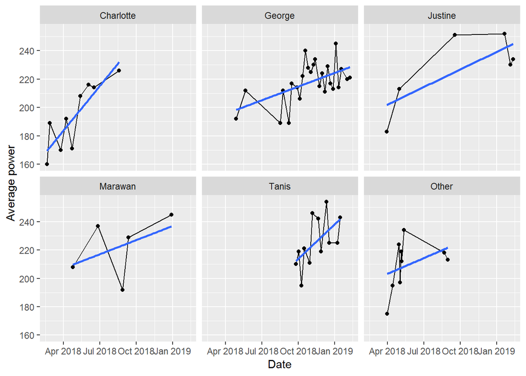

```r
ggplot2::ggplot(data, aes(x = Date, y = avg_power)) +
  ggplot2::geom_point() +
  ggplot2::geom_line() +
  ggplot2::geom_smooth(method = "lm", se = FALSE) +
  ggplot2::facet_wrap(~Instructor) +
  ggplot2::ylab("Average power")
```

Having eye-balled the charts. Let’s now look at a statistical model that considers just instructors.

```r
instructor_model <- update(time_model, . ~ Instructor)
summary(instructor_model)
```

```
##
## Call:
## lm(formula = avg_power ~ Instructor, data = data)
##
## Residuals:
##     Min      1Q  Median      3Q     Max
## -44.167 -10.590   0.663  13.540  32.000
##
## Coefficients:
##                   Estimate Std. Error t value Pr(>|t|)
## (Intercept)        194.000      6.123  31.683  < 2e-16 ***
## InstructorGeorge    23.840      7.141   3.339 0.001451 **
## InstructorJustine   33.167      9.682   3.426 0.001112 **
## InstructorMarawan   28.200     10.246   2.752 0.007817 **
## InstructorTanis     31.833      8.100   3.930 0.000222 ***
## InstructorOther     15.667      8.660   1.809 0.075433 .
## ---
## Signif. codes:  0 '***' 0.001 '**' 0.01 '*' 0.05 '.' 0.1 ' ' 1
##
## Residual standard error: 18.37 on 60 degrees of freedom
## Multiple R-squared:  0.2542, Adjusted R-squared:  0.1921
## F-statistic: 4.091 on 5 and 60 DF,  p-value: 0.002916
```

Each of the named instructors has a significant, positive effect on my average power. However, the overall R<sup>2</sup> is much less than the model that considered just time. So, our next step is to consider both together.

```r
time_instructor_model <- update(time_model, . ~ . + Instructor)
summary(time_instructor_model)
```

```
##
## Call:
## lm(formula = avg_power ~ Date + Instructor, data = data)
##
## Residuals:
##     Min      1Q  Median      3Q     Max
## -31.689 -11.132   1.039  10.800  26.267
##
## Coefficients:
##                     Estimate Std. Error t value Pr(>|t|)
## (Intercept)       -2332.4255   464.3103  -5.023 5.00e-06 ***
## Date                  0.1431     0.0263   5.442 1.07e-06 ***
## InstructorGeorge     -2.3415     7.5945  -0.308    0.759
## InstructorJustine    10.7751     8.9667   1.202    0.234
## InstructorMarawan    12.5927     8.9057   1.414    0.163
## InstructorTanis       3.3827     8.4714   0.399    0.691
## InstructorOther      12.3270     7.1521   1.724    0.090 .
## ---
## Signif. codes:  0 '***' 0.001 '**' 0.01 '*' 0.05 '.' 0.1 ' ' 1
##
## Residual standard error: 15.12 on 59 degrees of freedom
## Multiple R-squared:  0.5034, Adjusted R-squared:  0.4529
## F-statistic: 9.969 on 6 and 59 DF,  p-value: 1.396e-07
```

```r
anova(time_instructor_model, time_model)
```

```
## Analysis of Variance Table
##
## Model 1: avg_power ~ Date + Instructor
## Model 2: avg_power ~ Date
##   Res.Df   RSS Df Sum of Sq      F Pr(>F)
## 1     59 13481
## 2     64 15675 -5   -2193.8 1.9202 0.1045
```

This model has the best explanatory power so far and increases the coefficient for time slightly. This suggests that controlling for instructor improves the time signal. However, when we add in time, none of the individual instructors are significantly different from each other. My interpretation of this is that my overall improvement over time is much more important than which particular instructor is leading the class. Nonetheless, the earlier analysis of the instructors gave me some insights that I can use to maximize the contribution each of them makes to my overall progress. When comparing these models with an ANOVA though, we find that there isn’t a significant difference between them.

The last model to try is to look for a time by instructor interaction.

```r
time_instructor_interaction_model <- update(time_model, . ~ . * Instructor)
summary(time_instructor_interaction_model)
```

```
##
## Call:
## lm(formula = avg_power ~ Date + Instructor + Date:Instructor,
##     data = data)
##
## Residuals:
##     Min      1Q  Median      3Q     Max
## -31.328  -9.899   0.963  10.018  26.128
##
## Coefficients:
##                          Estimate Std. Error t value Pr(>|t|)
## (Intercept)            -5.881e+03  1.598e+03  -3.680 0.000540 ***
## Date                    3.442e-01  9.054e-02   3.801 0.000368 ***
## InstructorGeorge        4.225e+03  1.766e+03   2.393 0.020239 *
## InstructorJustine       3.704e+03  1.796e+03   2.062 0.044000 *
## InstructorMarawan       4.177e+03  2.137e+03   1.955 0.055782 .
## InstructorTanis         1.386e+03  2.652e+03   0.523 0.603313
## InstructorOther         3.952e+03  2.321e+03   1.703 0.094362 .
## Date:InstructorGeorge  -2.391e-01  9.986e-02  -2.394 0.020149 *
## Date:InstructorJustine -2.092e-01  1.016e-01  -2.059 0.044291 *
## Date:InstructorMarawan -2.357e-01  1.207e-01  -1.953 0.056070 .
## Date:InstructorTanis   -7.970e-02  1.492e-01  -0.534 0.595316
## Date:InstructorOther   -2.231e-01  1.314e-01  -1.698 0.095185 .
## ---
## Signif. codes:  0 '***' 0.001 '**' 0.01 '*' 0.05 '.' 0.1 ' ' 1
##
## Residual standard error: 14.86 on 54 degrees of freedom
## Multiple R-squared:  0.5609, Adjusted R-squared:  0.4715
## F-statistic: 6.271 on 11 and 54 DF,  p-value: 1.532e-06
```

```r
anova(time_model, time_instructor_interaction_model)
```

```
## Analysis of Variance Table
##
## Model 1: avg_power ~ Date
## Model 2: avg_power ~ Date + Instructor + Date:Instructor
##   Res.Df   RSS Df Sum of Sq      F Pr(>F)
## 1     64 15675
## 2     54 11920 10    3754.1 1.7006 0.1044
```

We can see that there are some significant interactions, meaning that the slope of improvement over time does differ by instructor. Before getting too excited though, an ANOVA shows that this model isn’t any better than the simple model of just time. There’s always a risk with trying to explain main effects (like time) with interactions. The story here is really that we need more data to tease out the impacts of the instructor by time effect.

The last point to make is that we’ve focused so far on the average power, since that’s the metric for this fitness challenge. There could be interesting interactions among average power, maximum power, RPMs, and total energy, each of which is available in these data. I’ll return to that analysis some other time.

In the interests of science, I’ll keep going to these classes, just so we can figure out what impact instructors have on performance. In the meantime, looks like I’ll succeed with at least this component of the fitness challenge and I have the stats to prove it.